# Image clustering for Bristol Medical School PGRS

- Aim of the course
- Data augmentation
- Geometric Transfromations
- Rotate the image
- Flip image horizontally
- Flip the image vertically
- Blur the image
- Visualise all images including the original image
- Resources
- General example - play ground

## Aim

To teach the concept of image clustering for analysis of medical images using a publicly available data set. The course will introduce ideas on data optimisation techniques with a focus on data augmentation, to improve machine learning in small imaging datasets.

# Data optimisation

- Focusing on refining existing data by cleaning, structuring, and removing redundancies to make it more efficient for analysis.

# Data augmentation

- Data augmentation is a technique of artificially increasing the training set by creating modified copies of a dataset using existing data.
- Aimed at creating new data points, manipulating existing data to increase the size and diversity of a dataset.

**Why is it important?**

1. Enhanced Model performance.  
   Data augmentation techniques help enrich datasets by creating many variations of existing data. This provides a larger dataset for training and enables a model to encounter more diverse features. The augmented data helps the model better generalize to unseen data and improve its overall performance in real-world environments.
2. To prevent models from overfitting.  
   Overfitting is the undesirable ML behavior where a model can accurately provide predictions for training data but it struggles with new data. If a model trains only with a narrow dataset, it can become overfit and can give predictions related to only that specific data type.
3. The initial training set is too small.
4. To improve the model accuracy.  
   If you need to train a deep learning model on sensitive data, you can use augmentation techniques on the existing data to create synthetic data.
5. To reduce the operational cost of labeling and cleaning the raw dataset.  
   Data augmentation techniques increase the effectiveness of smaller datasets, vastly reducing the dependency on large datasets in training environments.

**Example use case**

1. Health care - Image analysis.  
   Useful technology in medical imaging because it helps improve diagnostic models that detect, recognize, and diagnose diseases based on images. The creation of an augmented image provides more training data for models, especially for rare diseases that lack source data variations. The production and use of synthetic patient data advances medical research while respecting all data privacy considerations.

**How do you achieve Image data augmentation?**

- In image processing, applying transformations like rotations, flips, or color adjustments to existing images can help models generalize better.
- Other transformations are:

  i) *Color space transformations:* randomly change RGB color channels, contrast, and brightness. ii) *Kernel filters:* randomly change the sharpness or blurring of the image. iii) *Random erasing:* delete some part of the initial image. iv) *Mixing images:* blending and mixing multiple images.

## Geometric Transfromations

[figure not shown]

```python
# Load the necessary libraries
import skimage
import matplotlib.pyplot as plt
import matplotlib
import numpy as np

from skimage import data   ## Inbuilt dataset within scikit-image
from skimage import io, transform, filters, exposure
matplotlib.rcParams['font.size'] = 18
```

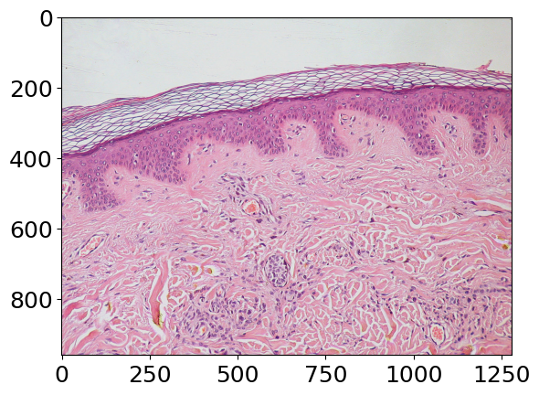

```python
# Load inbuilt skin dataset from scikit-image
image = data.skin()
image # displays an array representing the image
plt.imshow(image) # Visualise the original image
```

## Rotate the image

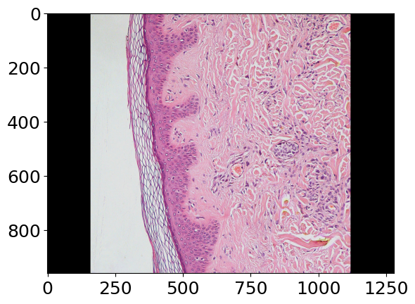

```python
# Rotate the image
rotated = transform.rotate(image, 90)  # Rotate 90 degrees
plt.imshow(rotated)
```